# analysis_show

## Analyze statistical characteristics of surface rupture data

### load compiled data

#### data source: Anderson et al. (2017), Biasi (2013), Wesnousky (2008) and FDHI

### Two analytical solution of surface rupture displacement

#### Shaw (2013)

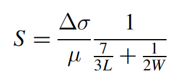

A generic version of Shaw's model is

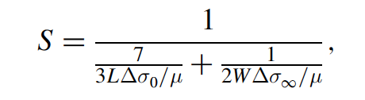

which contains two stress drops: Delta sigma_0 is the stress drop at smaller rupture length while Delta sigma_infinite is the stress drop at larger length

#### Chinnery (1963)

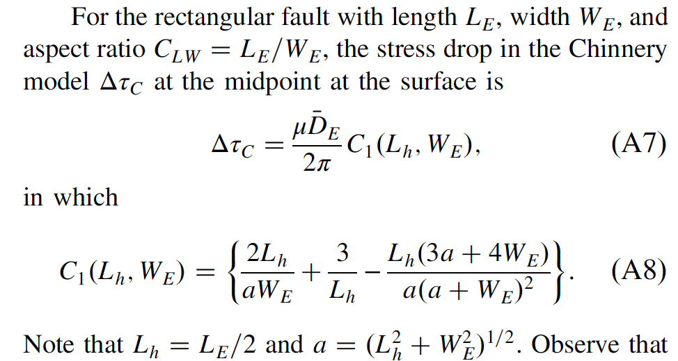

#### If fault is scale independent, i.e. stress drop and fault width are independent on the rupture length (thus magnitude)

```
(0.01, 100.0)
```

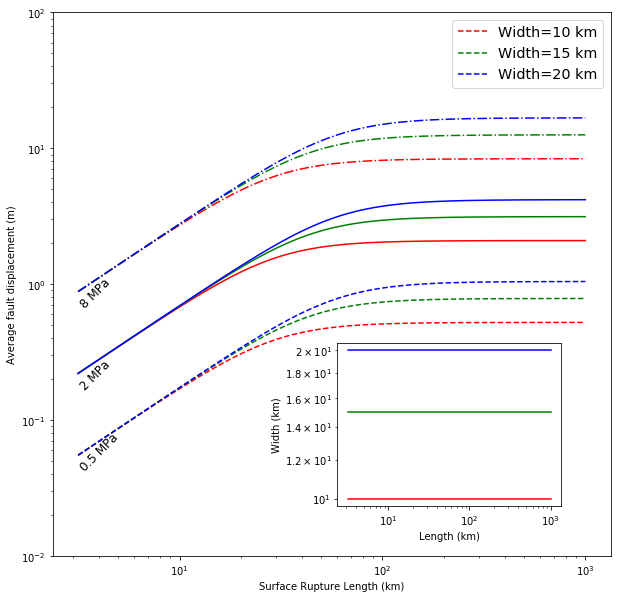

#### Let's see analytical prediction from a scale-dependent model (M1 stress drop is scale dependent; M2 width is scale dependent)

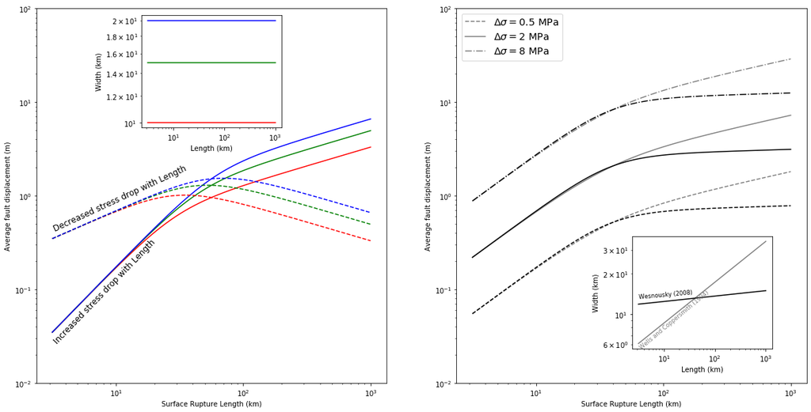

### Let's overlay the real data to see

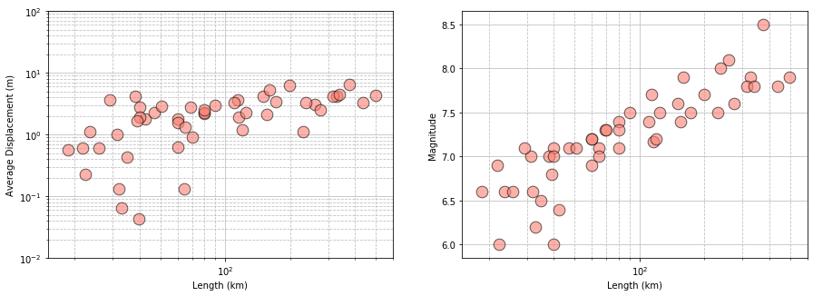

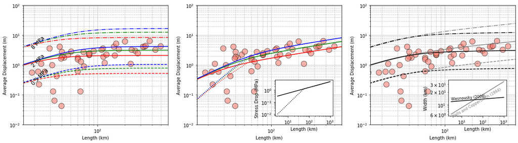

Above figures show that the model (Chinnery, 1963) with scale-independent stress drop and rupture width cannot fit the compiled data. Now we try Shaw (2013)'s model

```
(0.01, 100.0)
```

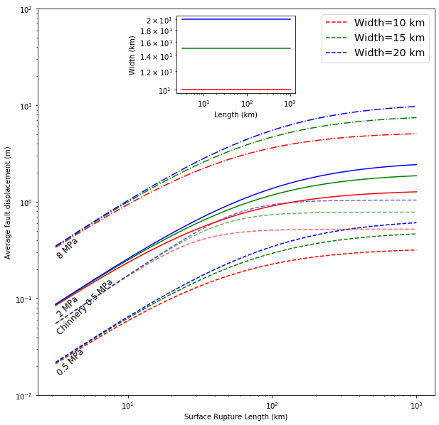

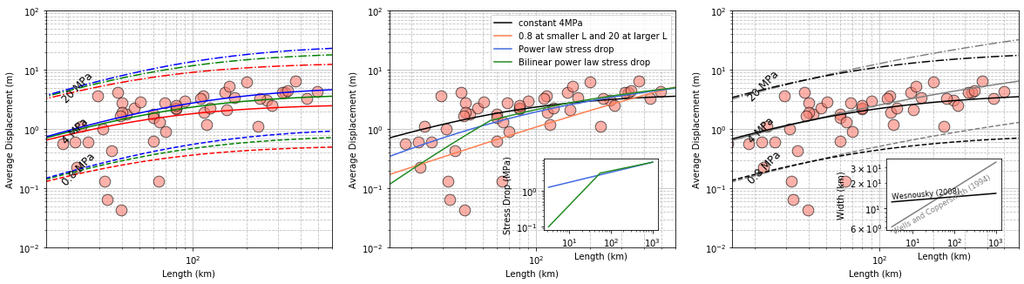

### Questions needed to be addressed:

Anderson et al. (1996,2017) claimed that including the fault-slip rate can improve scaling of magnitude versus rupture length and implied that the slip-rate (fault maturity) may affect the scaling. We collect the slip-rate data from the updated paper (Anderson et al, 2017) and some other materials and make a new dataset (including AD, M, L and SR) of 51 strike-slip earthquakes.

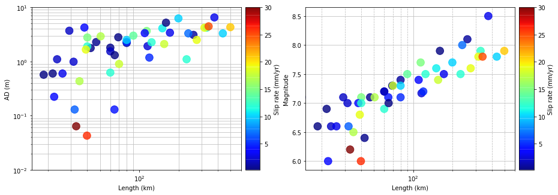

Anderson et al (2017) concluded that two groups of earthquake (larger and smaller than 4.8 mm/yr) show different scalings

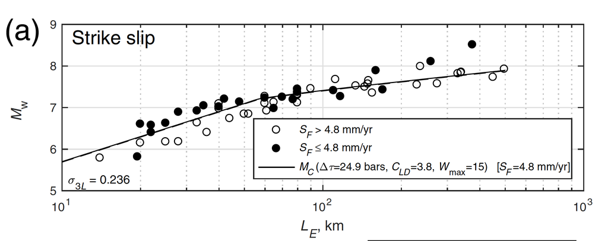

Slip rate may reflect the fault maturity, there are some studies showing the fault maturity will affect

- cumulative displacement
- slip rate
- fault initiation age
- stress drop
- earthquake occurence time
- asperity size
- seismicity localization width

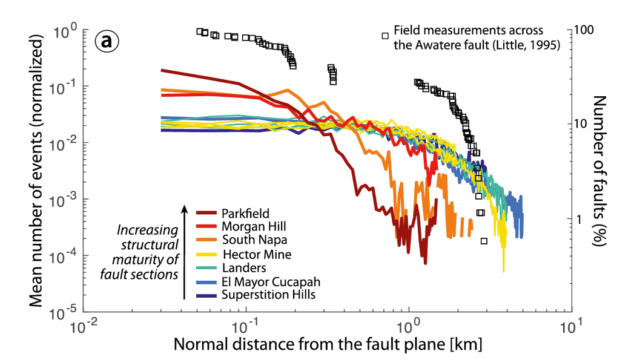

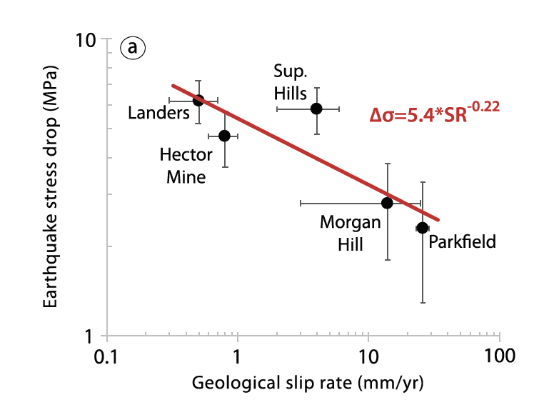

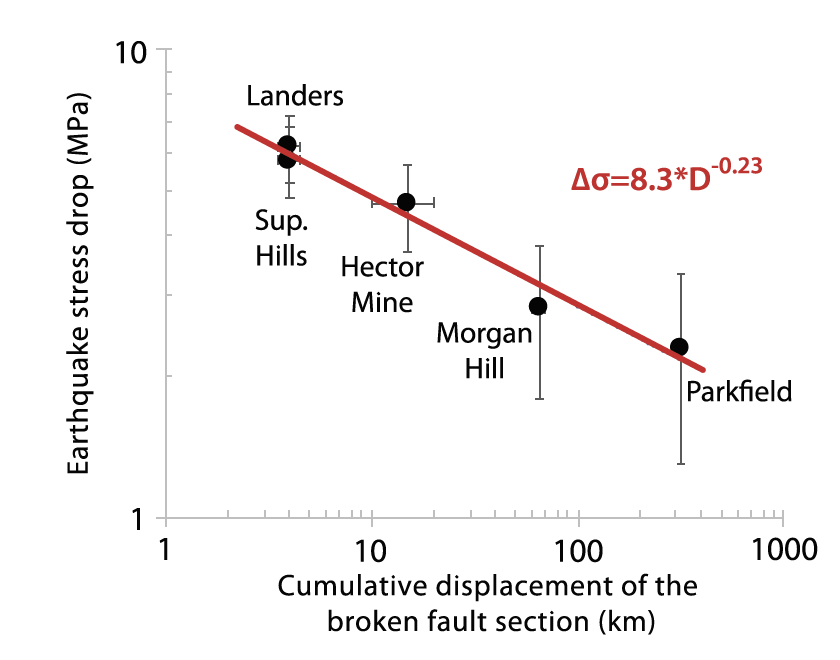

### Let's see our data again

#### We develop another matric to reflect the fault maturity (AD/SR) to mimic the average occurence time

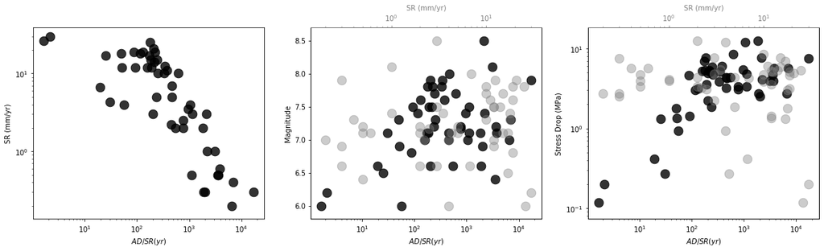

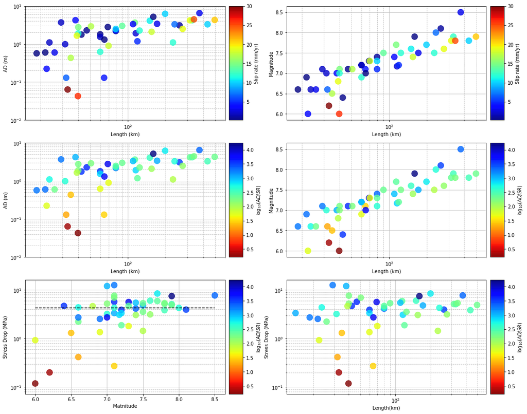

It is shown from the above figures that the lower left corner corresponds to a mature fault zone and the upper outlier corresponds to a immuture fault zone. It is consistent with Manighetti et al. (2007).

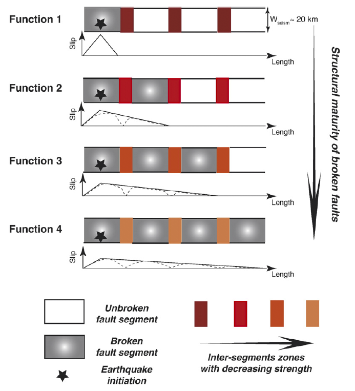

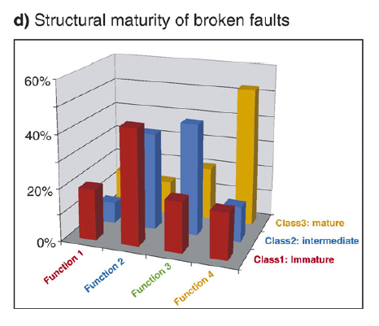

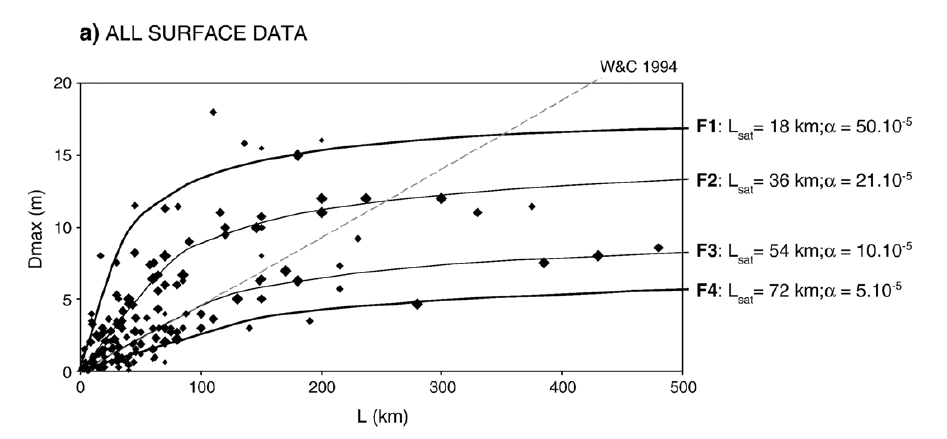

### We also overlay Manighetti (2007)'s models on our dataset

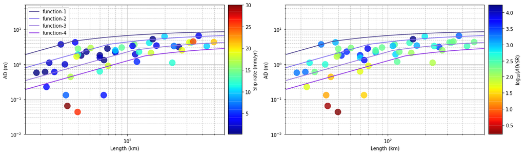